# R Notebook

JY

2024-11-26

# FILE STARTS HERE

## Testing Jimmy’s package

```r
# ...OR install from GitHub
library(devtools) # Make sure that the devtools library is loaded
install_github("https://github.com/jimmy-468/jy_text_semantic.git")
```

```
Using GitHub PAT from the git credential store.
Skipping install of 'JyTextSemantic' from a github remote, the SHA1 (3ad3fffc) has not changed since last install.
  Use `force = TRUE` to force installation
```

```r
# Activate and analyze package
# Use Ctrl + Enter to run individual lines of code
library(JyTextSemantic)

# access package documentation
packageDescription("JyTextSemantic")
```

```
Package: JyTextSemantic
Title: Semantic Text Analysis Algorithm (One Line, Title Case)
Version: 0.3
Authors@R: person("Jimmy", "Yu", , "jimmy.yu@ki.se", role = c("aut", "cre"),
        comment = c(ORCID = "YOUR-ORCID-ID"))
Description: A simple semantic algorithm for summarising negative and
        positive words in a document. Package creation and coding exercise,
        an KI-course H7F6003 assignment (one paragraph).
License: `use_mit_license()`
Encoding: UTF-8
Roxygen: list(markdown = TRUE)
RoxygenNote: 7.3.2
RemoteType: github
RemoteHost: api.github.com
RemoteRepo: jy_text_semantic
RemoteUsername: jimmy-468
RemoteRef: HEAD
RemoteSha: 3ad3fffc62c45192849f532f86dc3a2b980df4a3
GithubRepo: jy_text_semantic
GithubUsername: jimmy-468
GithubRef: HEAD
GithubSHA1: 3ad3fffc62c45192849f532f86dc3a2b980df4a3
NeedsCompilation: no
Packaged: 2024-11-27 10:54:04 UTC; Jimmy
Author: Jimmy Yu [aut, cre] (YOUR-ORCID-ID)
Maintainer: Jimmy Yu <jimmy.yu@ki.se>
Built: R 4.3.1; ; 2024-11-27 10:54:06 UTC; windows

-- File: C:/Users/crooa/AppData/Local/R/win-library/4.3/JyTextSemantic/Meta/package.rds
```

```r
help(package = "JyTextSemantic")

# access functions documentation
?JyTextSemantic::jy_text_analyser
#getAnywhere("jy_text_analyser")

#list functions and datasets
ls("package:JyTextSemantic")
```

```
[1] "jy_pos_neg_words"    "jy_text_analyser"    "jy_text_file_reader"
```

```r
#list datasets in package
data(package = "JyTextSemantic")
```

```r
# Then run the code
sample_text_file <- system.file("data", "Example_negative.txt",
        package = "JyTextSemantic")
jy_text_analyser(sample_text_file)
```

```
[1] "In .txt-file C:/Users/crooa/AppData/Local/R/win-library/4.3/JyTextSemantic/data/Example_negative.txt"
[1] "Positive words found: 6"
[1] "Negative words found: 7"
[1] "Ratio positive/negative words: (see below)"
[1] 0.4615385
```

```r
jy_text_analyser("../data/Example_instructions.txt")
```

```
[1] "In .txt-file ../data/Example_instructions.txt"
[1] "Positive words found: 42"
[1] "Negative words found: 19"
[1] "Ratio positive/negative words: (see below)"
[1] 0.6885246
```

## Testing Sabina’s package

```r
# Installing
library(devtools) # Make sure that the devtools library is loaded
install_github("https://github.com/Sabenl/ImageFilter.git")
```

```
Using GitHub PAT from the git credential store.
Skipping install of 'ImageFilter' from a github remote, the SHA1 (6f69ad72) has not changed since last install.
  Use `force = TRUE` to force installation
```

JYcomment: Installation went smoothly. The last output is copied to below:

```
* installing *source* package 'ImageFilter' ...
** using staged installation
** R
** byte-compile and prepare package for lazy loading
** help
*** installing help indices
** building package indices
** testing if installed package can be loaded from temporary location
** testing if installed package can be loaded from final location
** testing if installed package keeps a record of temporary installation path
* DONE (ImageFilter)
```

```r
# Activate and analyze package
# Use Ctrl + Enter to run individual lines of code
library(ImageFilter)

# access package documentation
packageDescription("ImageFilter")
```

```
Package: ImageFilter
Type: Package
Title: Applies different image filters to provided images
Version: 0.1.0
Author: Sabina Enlund
Maintainer: Sabina Enlund <sabina.enlund@ki.se>
Description: A package that contains different image filters to apply to you
        image.  Contains four different filters; grayscale, cutoff,
        red/green/blue and chosen color based on RBG values. Provide the
        path to your image and the package will enable you to apply the
        different filters and save the image to your directory.  You need
        to load your image path to the object "image_path" and load both
        the magick and ImageFilter library. Then you can use the provided
        "apply_filter" functions to generate a filtered image which can
        then be saved.
License: MIT + file LICENSE
Encoding: UTF-8
Imports: magick
RoxygenNote: 7.3.2
RemoteType: github
RemoteHost: api.github.com
RemoteRepo: ImageFilter
RemoteUsername: Sabenl
RemoteRef: HEAD
RemoteSha: 6f69ad723c5cc8ec155e30426166175ab78dad34
GithubRepo: ImageFilter
GithubUsername: Sabenl
GithubRef: HEAD
GithubSHA1: 6f69ad723c5cc8ec155e30426166175ab78dad34
NeedsCompilation: no
Packaged: 2024-11-26 22:12:35 UTC; Jimmy
Built: R 4.3.1; ; 2024-11-26 22:12:35 UTC; windows

-- File: C:/Users/crooa/AppData/Local/R/win-library/4.3/ImageFilter/Meta/package.rds
```

```r
help(package = "ImageFilter")

#list functions and datasets
ls("package:ImageFilter")
```

```
[1] "any_color_filter"        "apply_any_color_filter"  "apply_color_filter"
[4] "apply_cutoff_filter"     "apply_grayscale_filter"  "color_filter"
[7] "convert_raw_to_bitmap"   "grayscale_filter"        "grayscale_filter_cutoff"
```

```r
#list datasets in package
data(package = "ImageFilter")
```

```
no data sets found
```

```r
# access functions documentation
?any_color_filter
?apply_any_color_filter
?apply_color_filter
?apply_cutoff_filter
?apply_grayscale_filter
?color_filter
?convert_raw_to_bitmap
```

```
No documentation for ‘convert_raw_to_bitmap’ in specified packages and libraries:
you could try ‘??convert_raw_to_bitmap’
```

```r
?grayscale_filter
?grayscale_filter_cutoff
```

### Test run (of Sabinas package)

Using sample code adapted from readme-file on GitHub

```r
# Load libraries
library(ImageFilter)
library(magick)
```

```r
#Load the image
#Assign the path to the image you want to use in the filter (replace with your file path or image name if in the working directory)
image_path <- "../grp_peers_files/outlook stockholm.jpg"
```

JYcomment: I first tried changing working directory as I saw there was some file ops going on in the code, then realized I could change path

```r
#Apply the chosen filter to your image
#Assign the filter function to an object to be able to print and save the image

#Grayscale filter
gray_image <- apply_grayscale_filter(image_path)
#View the final image
print(gray_image)
```

| format | width | height | colorspace | matte | filesize | density |
| --- | --- | --- | --- | --- | --- | --- |
| PNG | 1420 | 1080 | sRGB | FALSE | 0 | 72x72 |

```r
#Save the final image as a JPEG, change path to the name and location desired
image_write(gray_image, path = "../grp_peers_files/gray_image.jpg", format = "jpeg")
```

JYcomment: Worked fine. I see a greyscale image in the Viewer pane. Got file output.

```r
#Cutoff filter to the grayscale vector (requires the grayscale filter to have been run first)
cutoff_image <- apply_cutoff_filter(image_path)
#View the final image
print(cutoff_image)
```

| format | width | height | colorspace | matte | filesize | density |
| --- | --- | --- | --- | --- | --- | --- |
| PNG | 1420 | 1080 | sRGB | FALSE | 0 | 72x72 |

```r
#Save the final image as a JPEG, change path to the name and location desired.
image_write(cutoff_image, path = "../grp_peers_files/cutoff_image.jpg", format = "jpeg")
```

JYcomment: Worked fine. I see a black-and-white image in the Viewer pane. Got file output.

```r
#Red, green or blue filter. Insert color "red", "blue" or "green" and change the output_path name.
color_image <- apply_color_filter(image_path, color = "red")
#View the final image
print(color_image)
```

| format | width | height | colorspace | matte | filesize | density |
| --- | --- | --- | --- | --- | --- | --- |
| PNG | 1420 | 1080 | sRGB | FALSE | 0 | 72x72 |

```r
#Save the final image as a JPEG, change path to the name and location desired.
image_write(color_image, path = "../grp_peers_files/color_image.jpg", format = "jpeg")
```

JYcomment: Worked fine. I see a red image in the Viewer pane. Got file output.

```r
#Any color filter, by supplying RGB values (any_color = c(0-255, 0-255, 0-255))
any_color_image <- apply_any_color_filter(image_path, any_color = c(255, 0, 255))
#View the final image
print(any_color_image)
```

| format | width | height | colorspace | matte | filesize | density |
| --- | --- | --- | --- | --- | --- | --- |
| PNG | 1420 | 1080 | sRGB | FALSE | 0 | 72x72 |

```r
#Save the final image as a JPEG, change path to the name and location desired.
image_write(any_color_image, path = "../grp_peers_files/any_color_image.jpg", format = "jpeg")
```

JYcomment: Worked fine. I see a magenta image in the Viewer pane. Got file output.

## Testing Fabians’s package

```r
# Installing
library(devtools) # Make sure that the devtools library is loaded
install_github("https://github.com/AMindOfMetalAndWheels/SchleichExam1New.git")
```

```
Using GitHub PAT from the git credential store.
Skipping install of 'SchleichExam1New' from a github remote, the SHA1 (d2653dab) has not changed since last install.
  Use `force = TRUE` to force installation
```

JYcomment: Installation process already done previously, went smoothly

```r
# Activate and analyze package
# Use Ctrl + Enter to run individual lines of code
library(SchleichExam1New)

# access package documentation
packageDescription("SchleichExam1New")
```

```
Package: SchleichExam1New
Type: Package
Title: Sliding window:An algorithm used on sequential data to smoothen it by
        first adding together series with a high increase and then taking
        the min value over a certain range.
Version: 0.1.0
Author: Who wrote it
Maintainer: Fabian Schleich <your.email@example.com>
Description: Here you can generate euclidean norm. Use a sliding window on
        your data to generate more "averaged" data. And plot it. Have fun!
License: MIT + file LICENSE
Encoding: UTF-8
Authors@R: person("Fabian", "Schleich", email = "fabian.schleich@ki.se",
        role = c("cre", "aut"))
URL: https://github.com/AMindOfMetalAndWheels/SchleichExam1Slide
BugReports:
        https://github.com/AMindOfMetalAndWheels/SchleichExam1Slide/issues
Imports: ggplot2, utils
Roxygen: list(markdown = TRUE)
RoxygenNote: 7.3.2
Suggests: testthat (>= 3.0.0)
Config/testthat/edition: 3
RemoteType: github
RemoteHost: api.github.com
RemoteRepo: SchleichExam1New
RemoteUsername: AMindOfMetalAndWheels
RemoteRef: HEAD
RemoteSha: d2653dabd26ec395dc1dd9bf2b63bb50ce0b8e99
GithubRepo: SchleichExam1New
GithubUsername: AMindOfMetalAndWheels
GithubRef: HEAD
GithubSHA1: d2653dabd26ec395dc1dd9bf2b63bb50ce0b8e99
NeedsCompilation: no
Packaged: 2024-11-26 20:30:53 UTC; Jimmy
Built: R 4.3.1; ; 2024-11-26 20:30:53 UTC; windows

-- File: C:/Users/crooa/AppData/Local/R/win-library/4.3/SchleichExam1New/Meta/package.rds
```

```r
help(package = "SchleichExam1New")

#list functions and datasets
ls("package:SchleichExam1New")
```

```
[1] "binary_window"          "euclidean"              "plot_euclidean_results"
[4] "process_euclidean_data" "smooth_window"
```

```r
#list datasets in package
data(package = "SchleichExam1New")
```

```
no data sets found
```

```r
# access functions documentation
?binary_window
?euclidean
?plot_euclidean_results
?process_euclidean_data
?smooth_window
```

JYcomment: All documentation in place. Instructions comprehensible.

### Test run (of Fabians package)

Using sample code adapted from function help documentation

```r
library(utils)
library(ggplot2)
library(testthat)
library(SchleichExam1New)
```

```r
test_check("SchleichExam1New")
```

```
Error in `test_dir()`:
! No test files found
Backtrace:
 1. testthat::test_check("SchleichExam1New")
 2. testthat::test_dir("testthat", package = package, reporter = reporter, ..., load_package = "installed")
```

JYcomment: it says “No test files found”, probably no dataset. Not a problem, I just download it from the course webpage and modify the file-read code below:

```r
# Load data
my_data <- utils::read.csv('../grp_peers_files/Example_window.csv')
```

JYcomment: Worked fine, I see `my_data` as a df in Environment, 45573 obs of 5 vars.  
Next up, some data transforms it seems

```r
# change column name X to Index
names(my_data)[1]<-paste("Index")

# Change time column
my_data$time <- as.POSIXct(my_data$time)
#subset data set for faster test
my_data2 <- my_data[c(1:250), c(1:5)]
```

JYcomment: Ran w/o errors

```r
# Test euclidean
SchleichExam1Slide::euclidean(my_data)
```

```
Error in loadNamespace(x) :
  there is no package called ‘SchleichExam1Slide’
```

JYcomment: got an error, probably old package name, I change it below:

```r
# Test euclidean and Store as data frame
euclidean_data <- euclidean(my_data)
```

JYcomment: this chunk ran fine, I got a new df `euclidean_data` with dims [45573, 6]  
Since the old package name seems to persist in ensuing code, so I’ve modified them too

```r
# Apply smooth_window function on raw data and on euclidean
smooth_data <- smooth_window(my_data, window_size = 100)
smooth_euclidean_data <- smooth_window(euclidean_data, window_size = 100)
```

JYcomment: code ran fine but `smooth_window()` took about 5-10s

```r
# Apply binary_window function on raw data and on euclidean
binary_data <- binary_window(my_data, window_size = 100)
binary_euclidean_data <- binary_window(euclidean_data, window_size = 100)
binary__smooth_euclidean_data <- binary_window(smooth_euclidean_data, window_size = 100)
```

JYcomment: code ran fine, each function took about 5s

```r
# test the combination function
process_euclidean_data(my_data, window_size = 100)
```

| Index | time | euclidean | mean | binary |
| --- | --- | --- | --- | --- |
| 1 | 2020-12-07 12:55:29 | 0.9388012 | 1.0529803 | -1 |
| 2 | 2020-12-07 12:55:29 | 0.9388012 | 1.0527063 | -1 |
| 3 | 2020-12-07 12:55:29 | 0.9388012 | 1.0521919 | -1 |
| 4 | 2020-12-07 12:55:29 | 0.9388012 | 1.0516744 | 1 |
| 5 | 2020-12-07 12:55:29 | 0.9388012 | 1.0513041 | -1 |
| 6 | 2020-12-07 12:55:29 | 0.9388012 | 1.0510610 | -1 |
| 7 | 2020-12-07 12:55:29 | 0.9388012 | 1.0510269 | -1 |
| 8 | 2020-12-07 12:55:29 | 0.9388012 | 1.0512749 | -1 |
| 9 | 2020-12-07 12:55:29 | 0.9508007 | 1.0515294 | -1 |
| 10 | 2020-12-07 12:55:29 | 0.9544049 | 1.0513952 | -1 |

[output cut: 990 more lines]

```r
my_ggplot_test <- process_euclidean_data(my_data, window_size = 1000)
```

JYcomment: code took about 10-20s, I got some empty output above, probably fine excited to see the result…

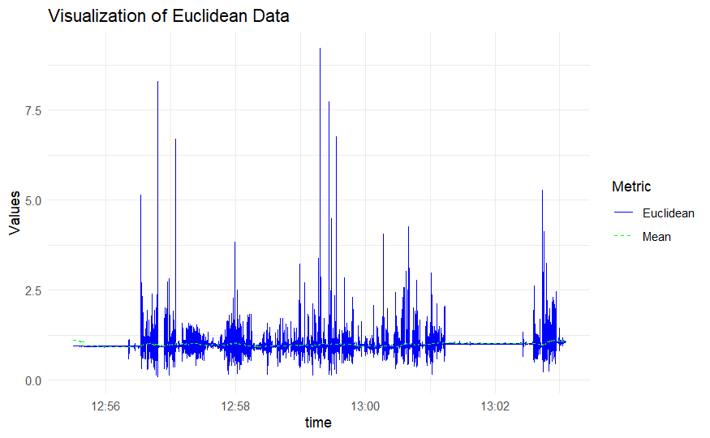

```r
# plot combination function
plot_euclidean_results(my_ggplot_test,include_mean = TRUE, include_binary = FALSE)
```

JYcomment: Yay! It worked! Graph looks awesome. It represents XYZ-acceleration as a acceleration-vector length (Euclidean) and a *smoothed* curve of the Euclidian using sliding window method (Mean). One pecularity that I do not understand is why the baseline acceleration is almost never 0 but always around 1? Perhaps it is gravity…